# Oncoplot Example

This notebook demonstrates the `oncoplot()` visualization, which displays somatic mutation patterns across genes and samples. The plot combines a mutation matrix with TMB per sample and gene alteration frequency panels.

For detailed documentation, see the [Oncoplot API Reference](https://luisruimor.github.io/pyMut/api/Visualization/oncoplot/).

- `include_silent`: Whether to include silent/synonymous mutations. Default: `False` (filters out silent variants to focus on protein-altering mutations, matching `maftools` behavior).

## Load Data

Load the MAF file and create a `PyMutation` object. The example uses the TCGA-LAML dataset.

```python
from pyMut.input import read_maf


maf_path = "../../../src/pyMut/data/examples/MAF/tcga_laml.maf.gz"
print(f'📂 Loading file: {maf_path}')

# Read the MAF file and create the PyMutation object
py_mutation = read_maf(maf_path,assembly="37")
```

from pyMut.input import read_maf maf_path = "../../../src/pyMut/data/examples/MAF/tcga_laml.maf.gz" print(f'📂 Loading file: {maf_path}') # Read the MAF file and create the PyMutation object py_mutation = read_maf(maf_path,assembly="37")

```
2026-10-13 14:21:30,672 | INFO | pyMut.input | Starting MAF reading: ../../../src/pyMut/data/examples/MAF/tcga_laml.maf.gz
```

```
2026-10-13 14:21:30,673 | INFO | pyMut.input | Loading from cache: ../../../src/pyMut/data/examples/MAF/.pymut_cache/tcga_laml.maf_8dc5feebdfe14cbc.parquet
```

```
2026-10-13 14:21:30,777 | INFO | pyMut.input | Cache loaded successfully in 0.11 seconds
```

```
📂 Loading file: ../../../src/pyMut/data/examples/MAF/tcga_laml.maf.gz
```

## Configure Plot Settings

Enable high-quality rendering settings for publication-ready figures.

```python
py_mutation.configure_high_quality_plots()
```

py_mutation.configure_high_quality_plots()

## Generate Oncoplot

The `oncoplot()` function creates a comprehensive visualization with four panels:

- **Center panel**: Mutation matrix showing gene-sample mutation status
- **Top panel**: Tumor Mutation Burden (TMB) per sample
- **Right panel**: Gene alteration frequency with percentage labels
- **Bottom panel**: Variant classification legend

```python
py_mutation.oncoplot()
```

py_mutation.oncoplot()

```
Oncoplot generated: 10 genes × 193 samples (1.94s)
```

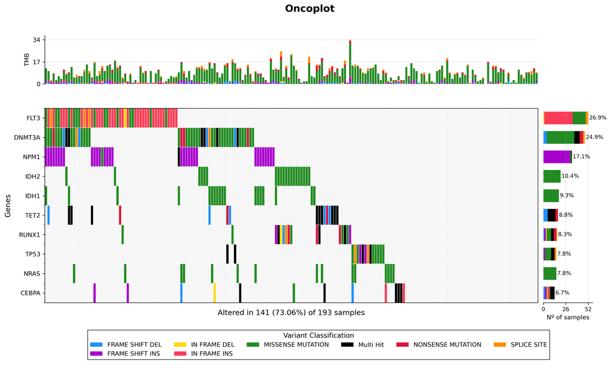